# ETC5521: Diving Deeply into Data Exploration

Making comparisons between groups and strata

Professor Di Cook

Department of Econometrics and Business Statistics

## At the heart of quantitative reasoning is a single question: Compared to what?

-Edward Tufte

## Making comparisons

- Groups defined by strata labelled in categorical variables
- Observations in strata, same or different?
- Is there a baseline, or normal value?
- What are the dependencies in the way the data was collected?
- Are multiple samples recorded for the same individual, or recorded on different individuals?

Determining the appropriate comparison is not always easy, but important to document when decided.

## How would you answer these questions?

- Are housing prices increasing more in Sydney or Melbourne?
- Is the rental price of the unit/apartment too high?
- Is the Alfred or Epworth Hospital better for giving birth?
- It’s hot and dry today, is the risk of bushfires too high to go hiking?

*ED-ie*

## Outline

- Comparing strata
- Paired, matched or repeated measurements
- Normalising, standardising, baseline, calibration
- When there is no data
- Including uncertainty
- The problem of making thousands of comparisons
- Generating comparison samples

## Comparing strata

## Case study: Melbourne’s daily maximum temperature (1/2)

- 📊
- data
- R

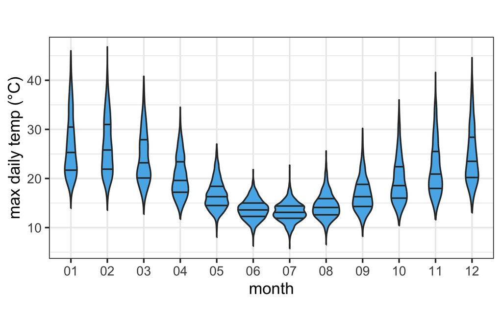

Melbourne’s daily maximum temperature from 1970 to 2020.

What are the strata in temporal data?

- How are the temperatures different across months?
- What about the temperature within a month?

```r
melb_temp <- read_csv(here::here("data", "melb_temp.csv")) |>
  janitor::clean_names() |>
  rename(temp = maximum_temperature_degree_c) |>
  filter(!is.na(temp)) |>
  dplyr::select(year, month, day, temp)
skimr::skim(melb_temp)
```

```
── Data Summary ────────────────────────
                           Values
Name                       melb_temp
Number of rows             18310
Number of columns          4
_______________________
Column type frequency:
  character                2
  numeric                  2
________________________
Group variables            None

── Variable type: character ────────────────────────────────
  skim_variable n_missing complete_rate min max empty
1 month                 0             1   2   2     0
2 day                   0             1   2   2     0
  n_unique whitespace
1       12          0
2       31          0

── Variable type: numeric ──────────────────────────────────
  skim_variable n_missing complete_rate   mean    sd     p0
1 year                  0             1 1995.  14.5  1970
2 temp                  0             1   19.9  6.48    5.7
     p25    p50    p75   p100 hist
1 1983   1995   2008   2020   ▇▇▇▇▇
2   14.8   18.6   23.6   46.8 ▃▇▃▁▁
```

```r
ggplot(melb_temp, aes(x=month, y=temp)) +
  geom_violin(draw_quantiles=c(0.25, 0.5, 0.75), fill= "#56B4E9") +
  labs(x = "month", y = "max daily temp (°C)") +
  theme(aspect.ratio=0.5)
```

## Case study: Melbourne’s daily maximum temperature (2/2)

Why can we make the comparison across months?

*Because it is the same location, and same years, for each month subset.*

Is some variation in temperature each month due to changing climate?

*How would you check this?*

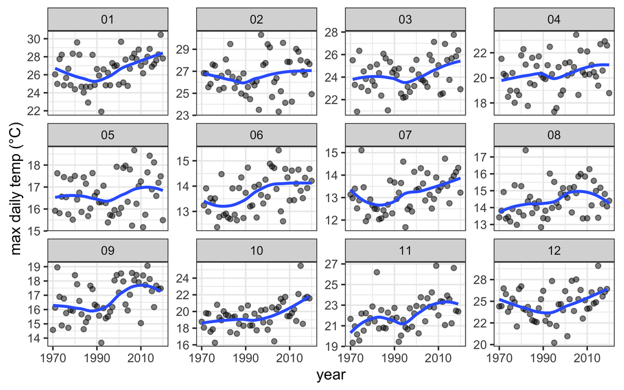

```r
melb_temp |>
  group_by(year, month) |>
  summarise(temp = mean(temp)) |>
  ggplot(aes(x=year, y=temp)) +
  geom_point(alpha=0.5) +
  geom_smooth(se=F) +
  facet_wrap(~month, ncol=4, scales="free_y") +
  scale_x_continuous("year", breaks=seq(1970, 2020, 20)) +
  ylab("max daily temp (°C)") +
  theme(aspect.ratio=0.7)
```

What is `scales="free_y"` for? *ED-ie*

## Activity: Seasonality over years

**Your turn**

What does change in seasonality mean?

1. Using `melb_temp`, compute the average max daily temperature for each `year` and `month`.
2. Make a line plot of temperature by month (x-axis), with one line connecting the dots for each year. Is there any evidence that the shape of the seasonal cycle has changed over time?
3. Years differ in their overall average temperature, which can make it hard to compare the *shape* of the seasonal cycle rather than its level. Try calibrating each year by dividing its monthly temperatures by that year’s average temperature, then remake the plot. Does this change what you see?
4. What does this calibration achieve, and what does it hide?
- Code
- Learn

*ED-ie*

```r
melb_temp_month <- melb_temp |>
  group_by(year, month) |>
  summarise(temp = mean(temp), .groups = "drop")

# raw comparison
ggplot(melb_temp_month,
    aes(x = month,
    y = temp,
    group = year,
    colour = year)) +
  geom_line(alpha = 0.4) +
  geom_point(alpha = 0.4) +
  ylab("max daily temp (°C)") +
  scale_x_discrete("", labels = c("J","F", "M", "A", "M", "J", "J", "A", "S", "O", "N", "D"))

# calibrated by each year's average temperature
melb_temp_month |>
  group_by(year) |>
  mutate(temp_cal = temp / mean(temp)) |>
  ungroup() |>
  ggplot(aes(x = month,
             y = temp_cal,
             group = year,
             colour = year)) +
  geom_line(alpha = 0.4) +
  geom_point(alpha = 0.4) +
  ylab("temp relative to yearly average") +   scale_x_discrete("", labels = c("J","F", "M", "A", "M", "J", "J", "A", "S", "O", "N", "D"))
```

- The raw line plot is dominated by year-to-year differences in overall temperature: warmer years sit above cooler years across all months, which makes it hard to compare the *shape* of the seasonal cycle.
- Dividing by each year’s average removes the level differences between years, so the lines overlap more and it becomes easier to compare the *timing* and *shape* of the seasonal peak and trough across years.
- This calibration also removes information about whether some years were warmer overall than others — it isn’t appropriate if the question of interest is about overall warming rather than seasonal shape.

## Case study: olive oils (1/4)

- 📊
- data
- R

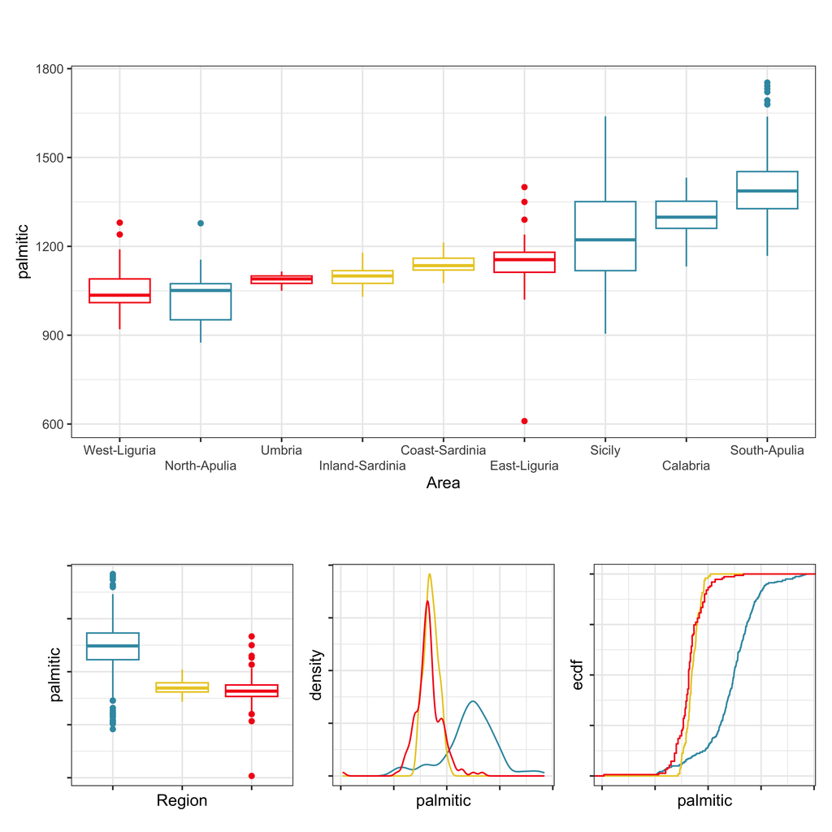

- The olive oil data consists of the percentage composition of 8 fatty acids (palmitic, palmitoleic, stearic, oleic, linoleic, linolenic, arachidic, eicosenoic) found in the lipid fraction of 572 Italian olive oils.
- There are 9 collection areas, 4 from southern Italy (North and South Apulia, Calabria, Sicily), two from Sardinia (Inland and Coastal) and 3 from northern Italy (Umbria, East and West Liguria).

```r
data(olives, package = "classifly")
df2 <- olives |>
  mutate(Region = factor(Region, labels = c("South", "Sardinia", "North")))

skimr::skim(df2)
```

```
── Data Summary ────────────────────────
                           Values
Name                       df2
Number of rows             572
Number of columns          10
_______________________
Column type frequency:
  factor                   2
  numeric                  8
________________________
Group variables            None

── Variable type: factor ───────────────────────────────────
  skim_variable n_missing complete_rate ordered n_unique
1 Region                0             1 FALSE          3
2 Area                  0             1 FALSE          9
  top_counts
1 Sou: 323, Nor: 151, Sar: 98
2 Sou: 206, Inl: 65, Cal: 56, Umb: 51

── Variable type: numeric ──────────────────────────────────
  skim_variable n_missing complete_rate   mean    sd   p0
1 palmitic              0             1 1232.  169.   610
2 palmitoleic           0             1  126.   52.5   15
3 stearic               0             1  229.   36.7  152
4 oleic                 0             1 7312.  406.  6300
5 linoleic              0             1  981.  243.   448
6 linolenic             0             1   31.9  13.0    0
7 arachidic             0             1   58.1  22.0    0
8 eicosenoic            0             1   16.3  14.1    1
     p25   p50    p75 p100 hist
1 1095   1201  1360   1753 ▁▂▇▆▁
2   87.8  110   169.   280 ▂▇▅▃▁
3  205    223   249    375 ▂▇▃▁▁
4 7000   7302. 7680   8410 ▁▇▇▇▁
5  771.  1030  1181.  1470 ▃▅▃▇▃
6   26     33    40.2   74 ▂▅▇▂▁
7   50     61    70    105 ▂▁▇▇▂
8    2     17    28     58 ▇▃▅▂▁
```

```r
g1 <-
  df2 |>
  mutate(Area = fct_reorder(Area, palmitic)) |>
  ggplot(aes(Area, palmitic, color = Region)) +
  geom_boxplot() +
  scale_color_discrete_divergingx(palette="Zissou 1") +
  guides(color = FALSE, x = guide_axis(n.dodge = 2)) +
  theme(aspect.ratio=0.5)

g2 <- ggplot(df2, aes(Region, palmitic, color = Region)) +
  geom_boxplot() +
  scale_color_discrete_divergingx(palette="Zissou 1") +
  guides(color = FALSE) +
  theme(axis.text = element_blank())

g3 <- ggplot(df2, aes(palmitic, color = Region)) +
  geom_density() +
  scale_color_discrete_divergingx(palette="Zissou 1") +
  guides(color = FALSE) +
  theme(axis.text = element_blank())

g4 <- ggplot(df2, aes(palmitic, color = Region)) +
  stat_ecdf() +
  scale_color_discrete_divergingx(palette="Zissou 1") +
  guides(color = FALSE) +
  theme(axis.text = element_blank())

g5 <- g2 + g3 + g4 + plot_layout(ncol=3)

g1 + g5 + plot_layout(ncol=1, heights=c(2,1),
  guides = "collect")
```

## Case study: olive oils (2/4)

- 📊
- R

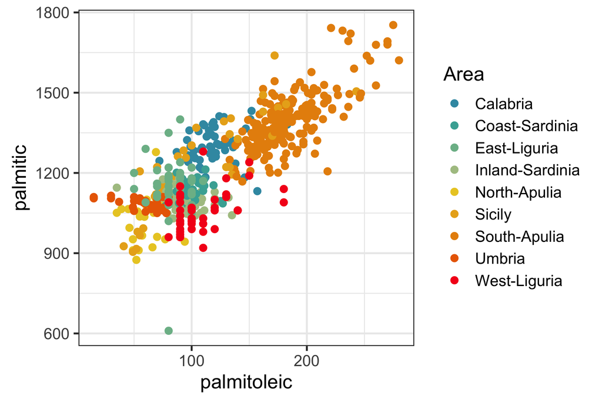

Colour is generally good to differentiate strata but if there are too many categories then it becomes hard to compare.

```r
ggplot(olives, aes(palmitoleic, palmitic, color = Area)) +
  geom_point() +
  scale_color_discrete_divergingx(palette="Zissou 1")
```

## Case study: olive oils (3/4)

- 📊
- R

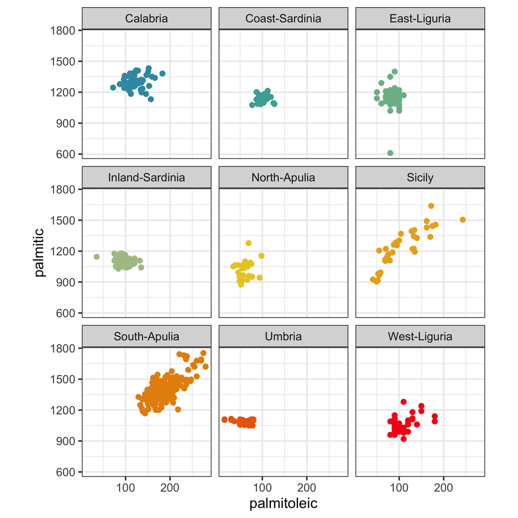

It can be hard to compare across plots, because we need to remember what the previous pattern was when focusing on the new cell.

```r
ggplot(olives, aes(palmitoleic, palmitic, color = Area)) +
  geom_point() +
  facet_wrap(~Area) +
  scale_color_discrete_divergingx(palette="Zissou 1") +
  guides(color = FALSE)
```

## Case study: olive oils (4/4)

- 📊
- R

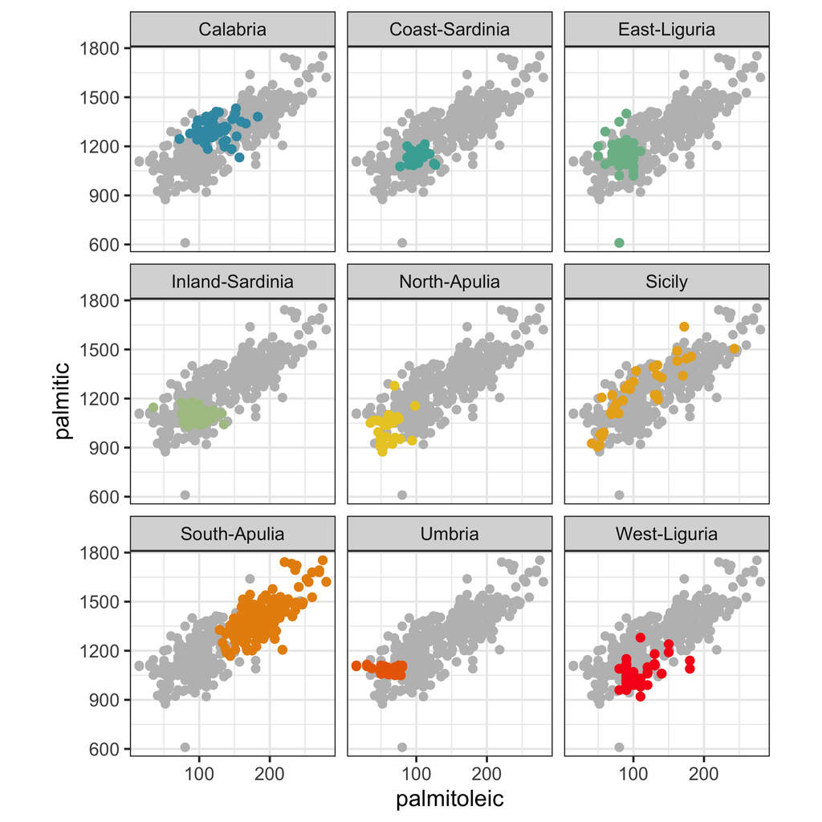

Comparison to all, by putting a shadow of all the data underneath the subset in each cell.

```r
ggplot(olives, aes(palmitoleic, palmitic)) +
  geom_point(data = dplyr::select(olives, -Area), color = "gray") +
  geom_point(aes(color = Area), size=2) +
  facet_wrap(~Area) +
  scale_color_discrete_divergingx(palette="Zissou 1") +
  guides(color = FALSE)
```

## Strata from quantitative variable

The coplot divides the numerical variable into chunks, and facets by these. The chunks traditionally we overlapping.

Becker, Cleveland and Shyu, (1996); Cleveland (1993)

```r
# Sizing of figure is difficult, so save it
library(ggcleveland)
olives_sard <- df2 |>
  filter(Region == "Sardinia")
p <- gg_coplot(olives_sard,
  x=arachidic, y=oleic,
  faceting = linoleic,
  number_bins = 6,
  overlap = 1/4) +
  theme(aspect.ratio=0.5)
```

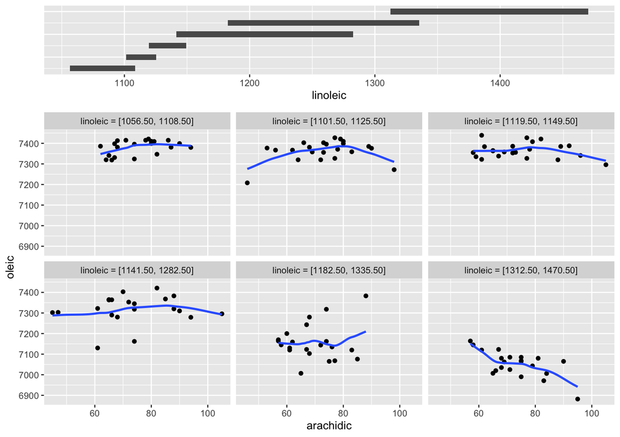

## Strata for categorical variables

```r
set.seed(42)

# Simulate a small employee-engagement survey
# 5 questions, 5-point Likert scale, 200 respondents

levels_5pt <- c(
  "Strongly disagree", "Disagree", "Neutral", "Agree", "Strongly agree"
)

survey_questions <- c(
  "My manager gives useful feedback",
  "I have the tools I need to do my job",
  "I understand how my work connects to company goals",
  "I feel comfortable raising concerns",
  "I would recommend this company as a place to work"
)

# Give each question a different underlying
# sentiment so the charts actually show
# a mix of positive/negative/mixed results
probs <- list(
  c(0.05, 0.10, 0.15, 0.40, 0.30),  # mostly positive
  c(0.20, 0.30, 0.20, 0.20, 0.10),  # skews negative
  c(0.05, 0.15, 0.50, 0.20, 0.10),  # mostly neutral
  c(0.15, 0.20, 0.10, 0.30, 0.25),  # mixed / bimodal-ish
  c(0.10, 0.15, 0.20, 0.30, 0.25)   # mildly positive
)

n_resp <- 200

survey_wide <- as_tibble(
  setNames(
    lapply(seq_along(survey_questions), function(i) {
      factor(
        sample(levels_5pt, n_resp, replace = TRUE, prob = probs[[i]]),
        levels = levels_5pt,
        ordered = TRUE
      )
    }),
    as.character(1:5)
  )
)

survey_long <- survey_wide |>
  pivot_longer(everything(),
    names_to = "question_num",
    values_to = "response") |>
  mutate(question = survey_questions[as.numeric(question_num)]) |>
  mutate(response = factor(response,
    levels = levels_5pt, ordered = TRUE),
    question = factor(question,
      levels = survey_questions))

stacked_data <- survey_long |>
  count(question_num, response) |>
  group_by(question_num) |>
  mutate(pct = n / sum(n)) |>
  ungroup()
```

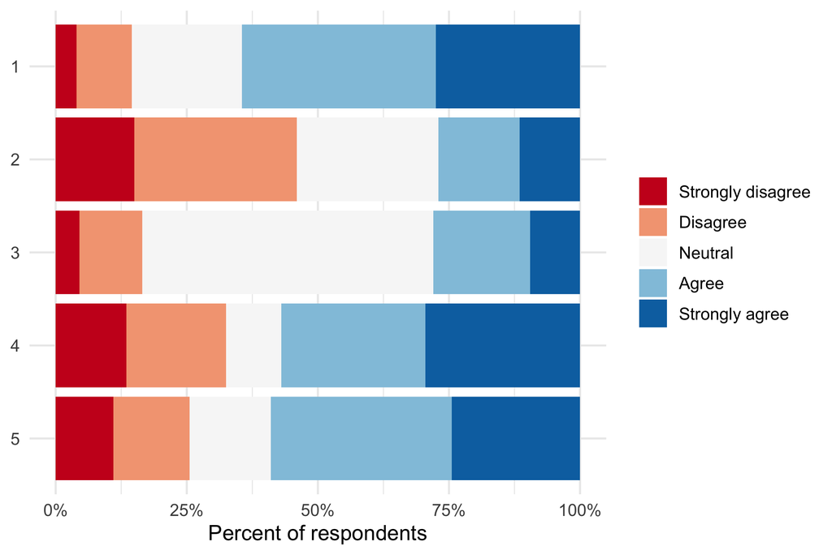

```r
plain_stacked_bar <- ggplot(stacked_data,
    aes(x = pct,
        y = question_num,
        fill = response)) +
  geom_col(position = position_stack(reverse = TRUE)) +
  scale_fill_brewer(palette = "RdBu", direction = 1) +
  scale_x_continuous(labels = scales::percent) +
  scale_y_discrete(limits = rev) +
  labs(
    x = "Percent of respondents", y = NULL, fill = NULL
  ) +
  theme_minimal()
plain_stacked_bar
```

The questions are: 1 My manager gives useful feedback, 2 I have the tools I need to do my job, 3 I understand how my work connects to company goals, 4 I feel comfortable raising concerns, 5 I would recommend this company as a place to work

Rank the 5 questions by “most disagreement”.

*ED-ie*

A Likert plot centres the bar on the neutral category.

- gglikert
- Sorted

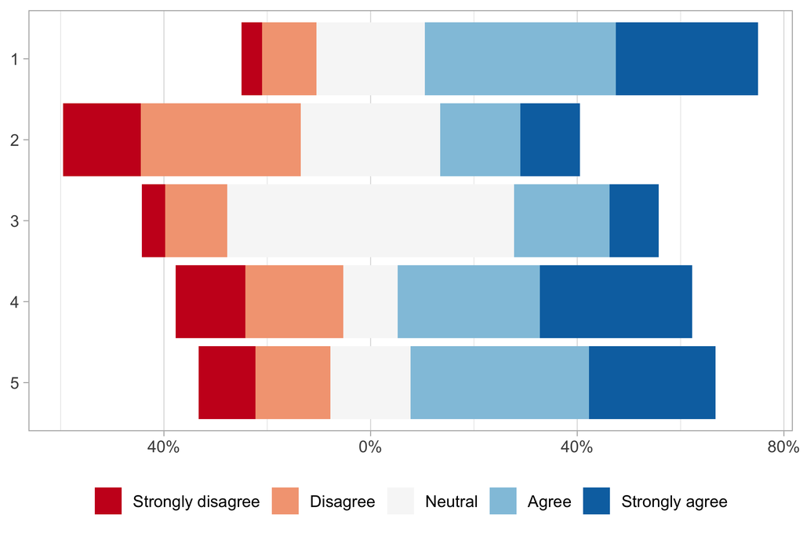

```r
library(ggstats)
likert_plot <- gglikert(
  survey_wide,
  add_labels = FALSE,
  add_totals = FALSE
) +
  scale_fill_brewer(palette = "RdBu", direction = 1)
likert_plot
```

NOTE: Also a good idea to sort questions (not done here).

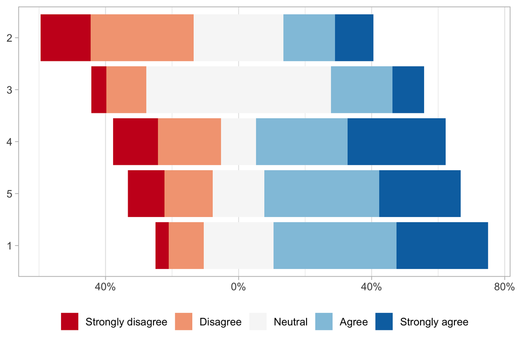

```r
library(ggstats)
likert_plot <- gglikert(
  survey_wide,
  add_labels = FALSE,
  add_totals = FALSE,
  sort = "ascending"
) +
  scale_fill_brewer(palette = "RdBu", direction = 1)
likert_plot
```

## Simple rearranging comparisons: tuberculosis (1/3)

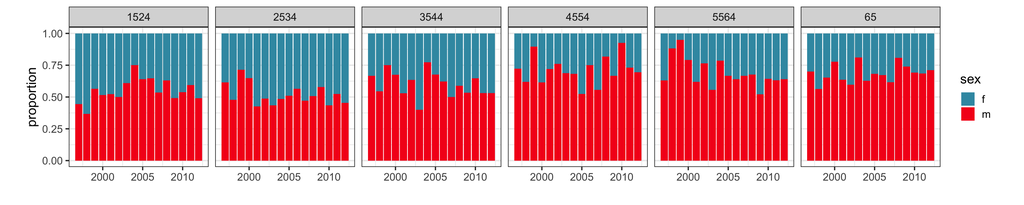

```r
tb_oz |>
  ggplot(aes(x=year, y=count, fill=sex)) +
    geom_col(position="fill") +
    scale_fill_discrete_divergingx(palette = "Zissou 1") +
    facet_wrap(~age, ncol=6) +
    xlab("") + ylab("proportion")
```

Primary comparison is `sex`, relative to yearly trend.

## Simple rearranging comparisons: tuberculosis (2/3)

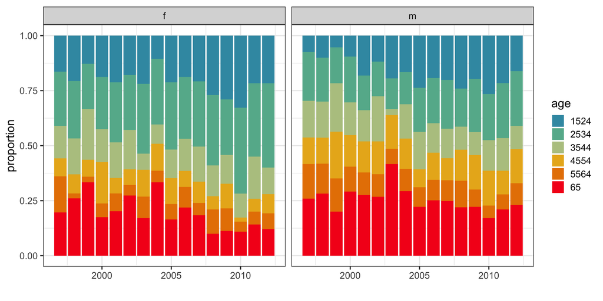

```r
tb_oz |>
  ggplot(aes(x=year, y=count, fill=age)) +
    geom_col(position="fill") +
    scale_fill_discrete_divergingx(palette = "Zissou 1") +
    facet_wrap(~sex, ncol=2) +
    xlab("") + ylab("proportion")
```

Primary comparison is `age`, relative to yearly trend.

## Simple rearranging comparisons: tuberculosis (3/3)

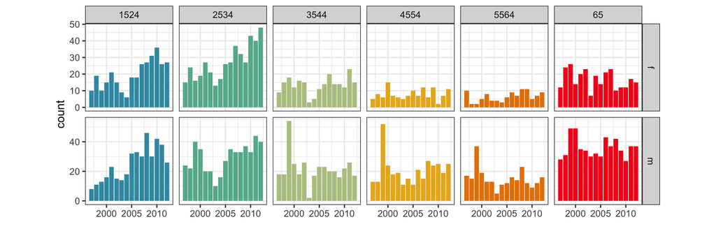

```r
tb_oz |>
  ggplot(aes(x=year, y=count, fill=age)) +
    geom_col() +
    scale_fill_discrete_divergingx(palette = "Zissou 1") +
    facet_grid(sex~age, scales="free") +
    xlab("") + ylab("count") +
    theme(legend.position = "none")
```

Primary comparison is `year` trend, separately for age and sex.

## Paired, matched or repeated measurements

## Pairing adjusts for individual differences

If we were wanting to measure the effect of incorporating a data analytics competition on student learning which is the best design?

METHOD A

- Divide students into two groups. Make sure that each group has similar types of students, so both groups are as similar as possible.
- One group gets an extra traditional assignment, and the other group participates in a data competition.
- Each student takes an exam on the content being taught.
- The scores are compared using side-by-side boxplots and a two-sample permutation test

METHOD B

- Each student takes an exam on the content being taught. We’ll call this their BEFORE score.
- Divide students into two groups. Make sure that each group has similar types of students, so both groups are as similar as possible.
- One group gets an extra traditional assignment, and the other group participates in a data competition.
- Each student takes an exam on the content being taught. We’ll call this their AFTER score.
- The difference between the before and after scores are compared using side-by-side boxplots and a two-sample permutation test

What other modifications to the design can you think of?

## Case study: choropleth vs hexagon tile (1/3)

The goal is to demonstrate that the *hexagon tile map is better than the choropleth* for communicating disease incidence across Australia.

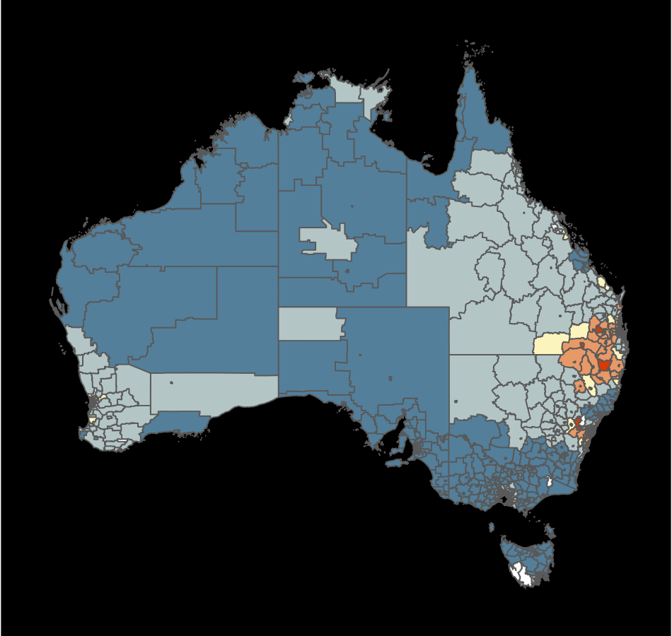

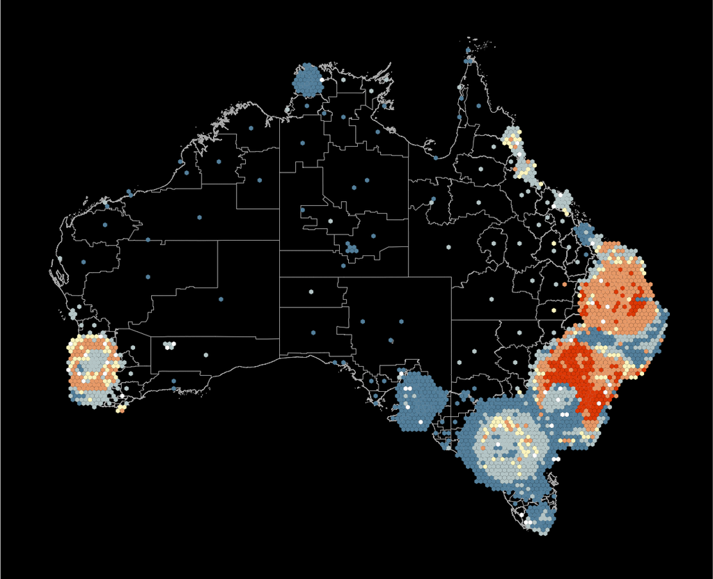

The choropleth fills geographic regions (LGAs, SA2s, …) with colour corresponding to the thyroid cancer relative difference from the overall mean. The hexagons, are also filled this way.

[Kobakian et al](https://github.com/srkobakian/experiment/blob/master/paper/paper.pdf)

## Case study: choropleth vs hexagon tile (2/3)

- Each participant can only see the (same) data once.
- Need to test for different types of spatial patterns.
- Need to repeat measure each type of pattern, and each participant.

Pairing is done on the data set. Four different data sets used for each pattern.

**Trial 1**

*Participant 1*

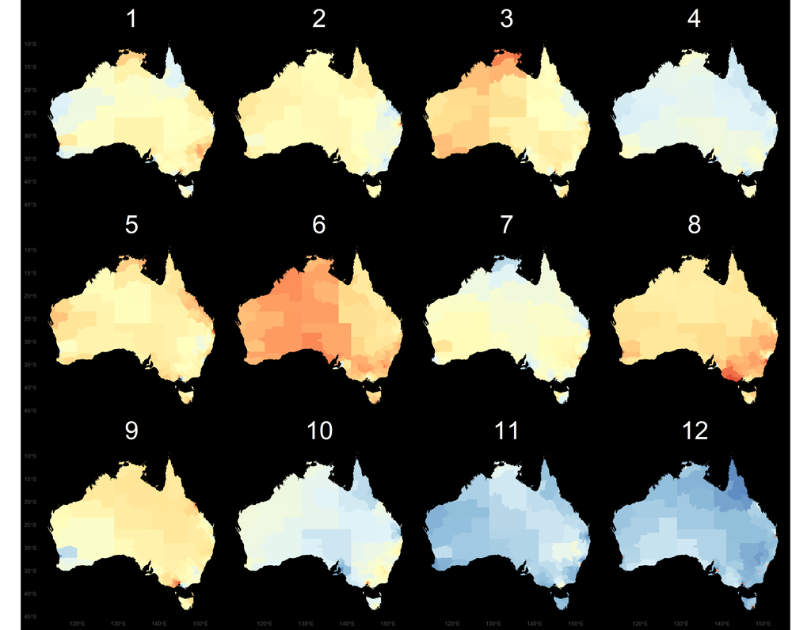

*Participant 2*

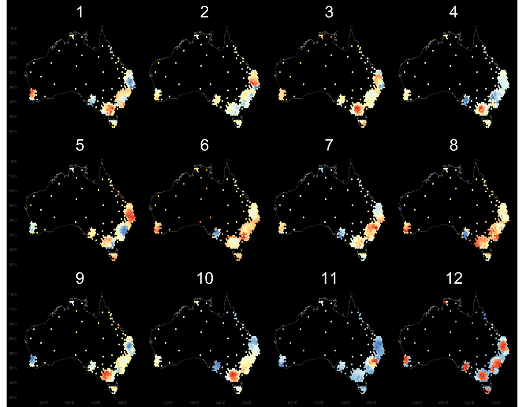

**Trial 2**

*Participant 1*

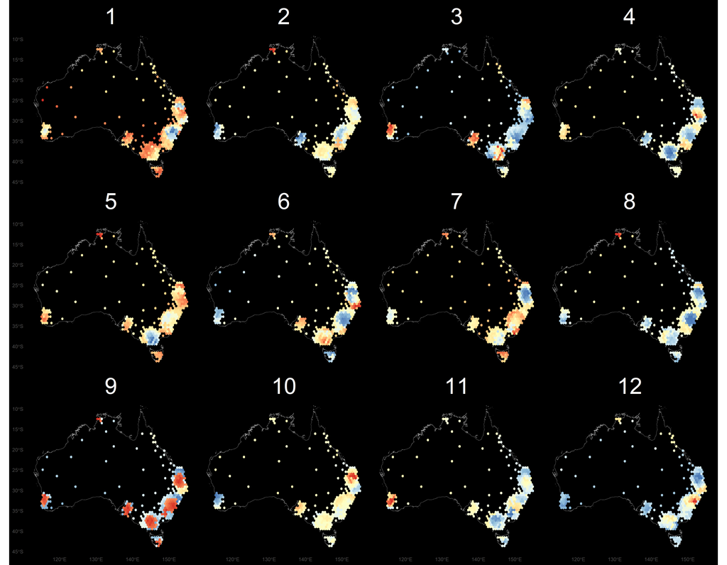

*Participant 2*

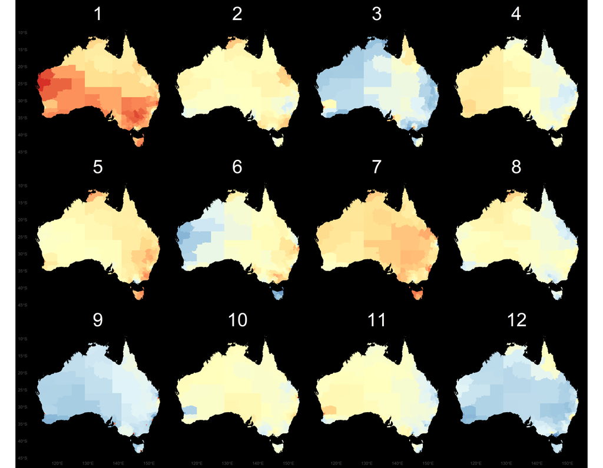

## Case study: choropleth vs hexagon tile (3/3)

**Ignore the pairing**

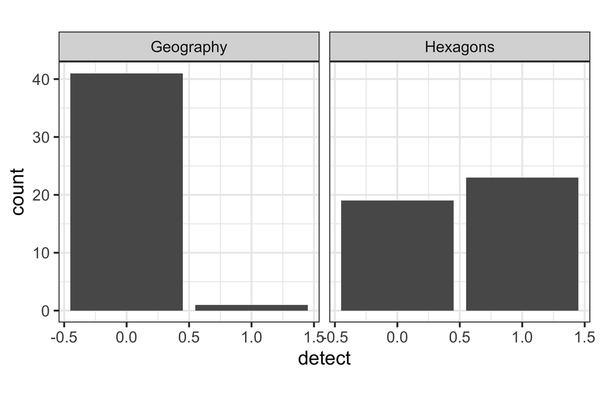

```r
hstudy <- read_csv("https://raw.githubusercontent.com/srkobakian/experiment/master/data/DAT_HexmapPilotData_V1_20191115.csv")
hstudy |>
  filter(trend == "three cities") |>
  ggplot(aes(x=detect)) + geom_bar() + facet_wrap(~type, ncol=2)
```

Looks like detection rate about 50-50 for hexagon tile map, which is better than almost zero for choropleth map.

**Account for the pairing**

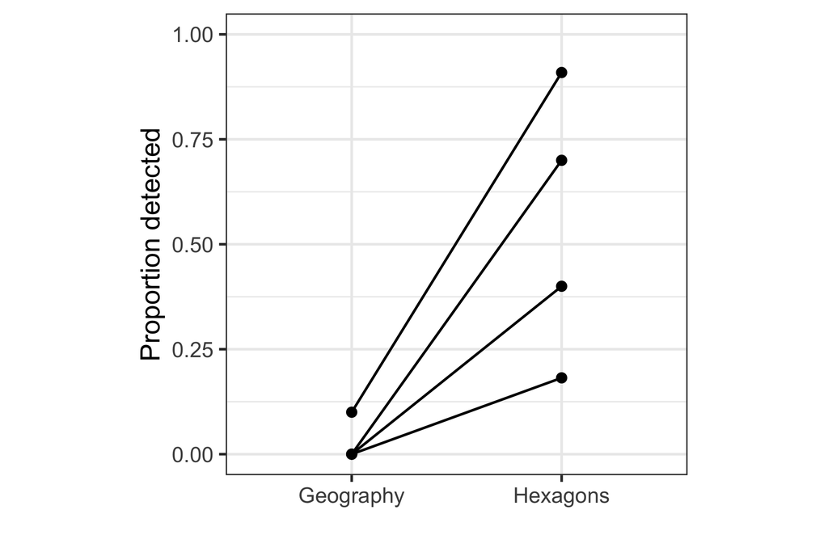

```r
hstudy |>
  filter(trend == "three cities") |>
  select(type, replicate, detect) |>
  group_by(type, replicate) |>
  summarise(pdetect = length(detect[detect == 1])/length(detect)) |>
  ggplot(aes(x=type, y=pdetect)) +
    geom_point() +
    geom_line(aes(group=replicate)) +
    ylim(c(0,1)) +
    xlab("") +
    ylab("Proportion detected")
```

For each data set, the hexagon tile map performed better.

## Normalising, standardising, baseline, calibration

## Famous example: trade

- 📊
- data
- R

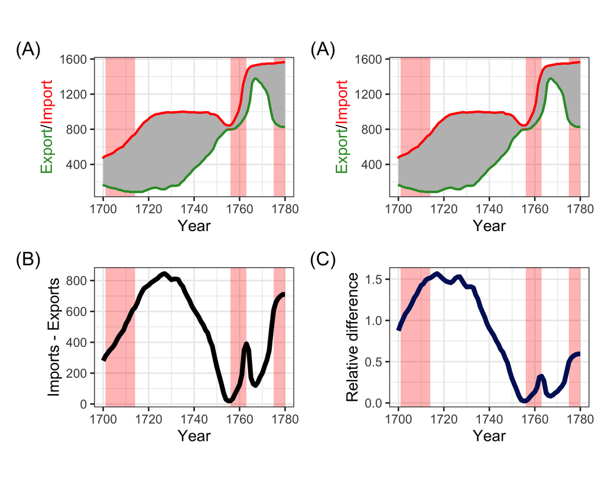

- The export from England to the East Indies and the import to England from the East Indies in millions of pounds (A).
- Import and export figures are easier to compare by plotting the difference like in (B).
- Relative difference may be more of an interest: (C) plots the relative difference with respect to the average of export and import values.
- The red area correspond to War of the Spanish Succession (1701-14), Seven Years’ War (1756-63) and the American Revolutionary War (1775-83).

```r
data(EastIndiesTrade, package = "GDAdata")
skimr::skim(EastIndiesTrade)
```

```
── Data Summary ────────────────────────
                           Values
Name                       EastIndiesTrade
Number of rows             81
Number of columns          3
_______________________
Column type frequency:
  numeric                  3
________________________
Group variables            None

── Variable type: numeric ──────────────────────────────────
  skim_variable n_missing complete_rate  mean    sd   p0
1 Year                  0             1 1740   23.5 1700
2 Exports               0             1  518. 421.   100
3 Imports               0             1 1005. 320.   460
   p25  p50  p75 p100 hist
1 1720 1740 1760 1780 ▇▇▇▇▇
2  145  370  840 1395 ▇▂▃▂▂
3  835  975 1000 1550 ▃▃▇▁▅
```

```r
g1 <- ggplot(EastIndiesTrade, aes(Year, Exports)) +
  annotate("rect",
    xmin = 1701, xmax = 1714,
    ymin = -Inf, ymax = Inf,
    fill = "red", alpha = 0.3
  ) +
  annotate("rect",
    xmin = 1756, xmax = 1763,
    ymin = -Inf, ymax = Inf,
    fill = "red", alpha = 0.3
  ) +
  annotate("rect",
    xmin = 1775, xmax = 1780,
    ymin = -Inf, ymax = Inf,
    fill = "red", alpha = 0.3
  ) +
  geom_line(color = "#339933", size = 2) +
  geom_line(aes(Year, Imports), color = "red", size = 2) +
  geom_ribbon(aes(ymin = Exports, ymax = Imports), fill = "gray") +
  labs(y = "<span style='color:#339933'>Export</span>/<span style='color:red'>Import</span>", tag = "(A)") +
  theme(aspect.ratio=0.7, axis.title.y = ggtext::element_markdown())

g2 <- ggplot(EastIndiesTrade, aes(Year, Imports - Exports)) +
  annotate("rect",
    xmin = 1701, xmax = 1714,
    ymin = -Inf, ymax = Inf,
    fill = "red", alpha = 0.3
  ) +
  annotate("rect",
    xmin = 1756, xmax = 1763,
    ymin = -Inf, ymax = Inf,
    fill = "red", alpha = 0.3
  ) +
  annotate("rect",
    xmin = 1775, xmax = 1780,
    ymin = -Inf, ymax = Inf,
    fill = "red", alpha = 0.3
  ) +
  geom_line(size = 2) +
  labs(tag = "(B)") +
  theme(aspect.ratio=0.7)

g3 <- ggplot(EastIndiesTrade, aes(Year, (Imports - Exports) / (Exports + Imports) * 2)) +
  annotate("rect",
    xmin = 1701, xmax = 1714,
    ymin = -Inf, ymax = Inf,
    fill = "red", alpha = 0.3
  ) +
  annotate("rect",
    xmin = 1756, xmax = 1763,
    ymin = -Inf, ymax = Inf,
    fill = "red", alpha = 0.3
  ) +
  annotate("rect",
    xmin = 1775, xmax = 1780,
    ymin = -Inf, ymax = Inf,
    fill = "red", alpha = 0.3
  ) +
  geom_line(color = "#001a66", size = 2) +
  labs(y = "Relative difference", tag = "(C)") +
  theme(aspect.ratio=0.7)

g1 + g1 + g2 + g3 + plot_layout(ncol=2)
```

## Am I short?

I am 165 cms tall.

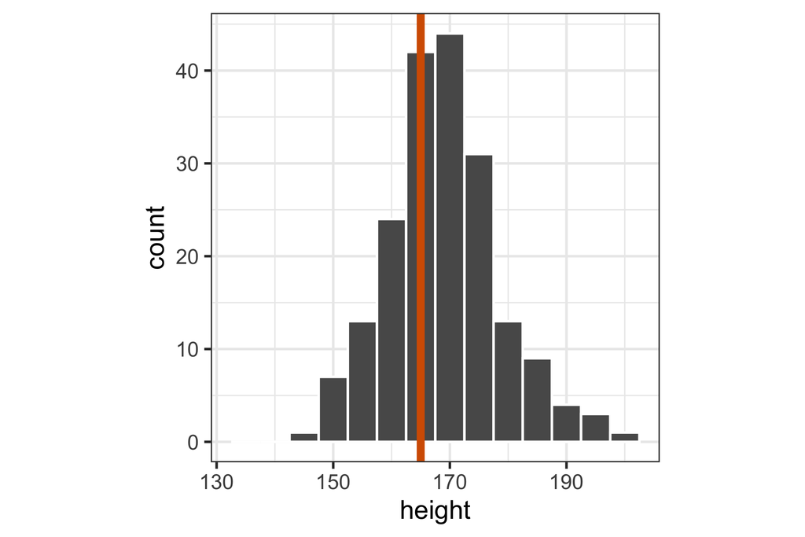

```r
ggplot(df22, aes(x=height)) +
  geom_histogram(breaks = seq(132.5, 205, 5),
    colour="white") +
  geom_vline(xintercept = 165, colour="#D55E00",
    linewidth=2)
```

But, there are strata in humans, so compared to what would be better?

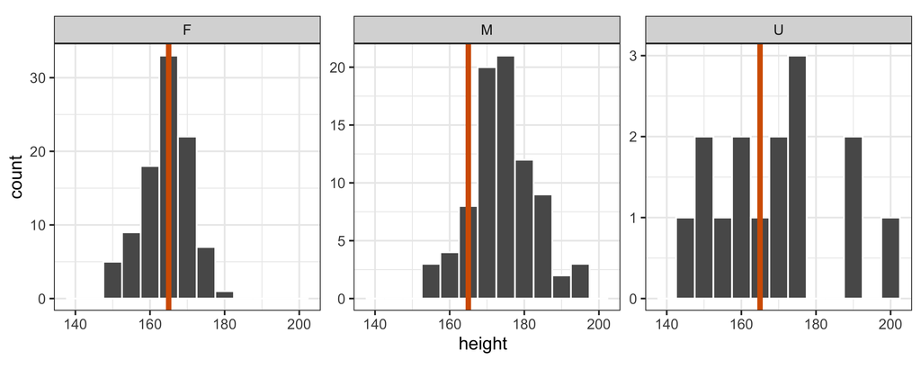

```r
ggplot(df22, aes(x=height)) +
  geom_histogram(breaks = seq(137.5, 205, 5),
    colour="white") +
  geom_vline(xintercept = 165, colour="#D55E00",
    linewidth=2) +
  facet_wrap(~sex, ncol=3, scales="free_y")
```

Nope, I’m average height.

## Standardising

Within each strata convert values to a z-score.

$$z = \frac{x-\bar{x}}{s}$$

```r
df22 <- df22 |>
  group_by(sex) |>
  mutate(zscore = (height -
    mean(height))/sd(height))
```

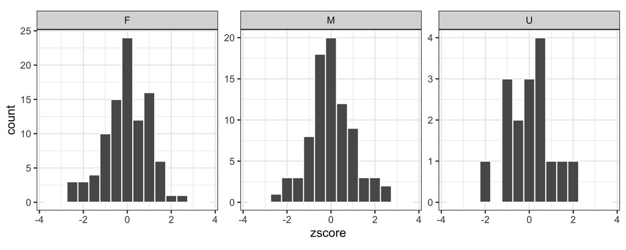

- females: $\bar{x}=$ 164.43, $s=$ 6.41
- males: $\bar{x}=$ 174.23, $s=$ 8.71
- unknown: $\bar{x}=$ 165.74, $s=$ 18.15

My z-score is 0.09.

Rob’s height is 170 cms. His z-score is -0.49.

I am relatively TALLER than Rob.

## Range of standardising methods

*Put values on the same footing so different subgroups can be compared*

| Method | Formula | Use when |
| --- | --- | --- |
| **Z-score** | $(x-\mu)/\sigma$ | Roughly normal, no big outliers |
| **Min-max** | $(x-x_{min})/(x_{max}-x_{min})$ | Need a bounded [0,1] range |
| **Robust scaling** | $(x-\text{median})/\text{IQR}$ | Outliers / skew present |
| **Unit vector norm** | $x/\lVert x \rVert$ | Care about direction, not magnitude |
| **Rate / per-unit** | $x/\text{exposure}$ | Comparing groups of different size |
| **Index / rebase** | $100 \times x/x_{base}$ | Comparing trends across units |
| **Percentile rank** | rank$(x)$ | Compare relative standing |

What happens when denominator is small with some of these metrics? *ED-ie*

## Common ways to standardise observations

*Put rows on the same footing so different individuals/units can be compared*

| Method | Formula | Use when |
| --- | --- | --- |
| **Ipsatization** | $x_{ij}-\bar{x}_i$ | Respondents differ in baseline scale use |
| **Row z-score** | $(x_{ij}-\bar{x}_i)/s_i$ | Respondents differ in spread too |
| **Compositional %** | $x_{ij}/\sum_j x_{ij}$ | Compare *allocation pattern*, not scale |
| **Library-size norm.** | adjust for exposure/depth | Unequal measurement effort per unit |
| **Unit norm (row)** | $x/\lVert x \rVert$ | Compare pattern, not magnitude (e.g. text) |
| **Rank-within-row** | rank across own items | Avoid scale-use differences entirely |

## Comparing with a baseline

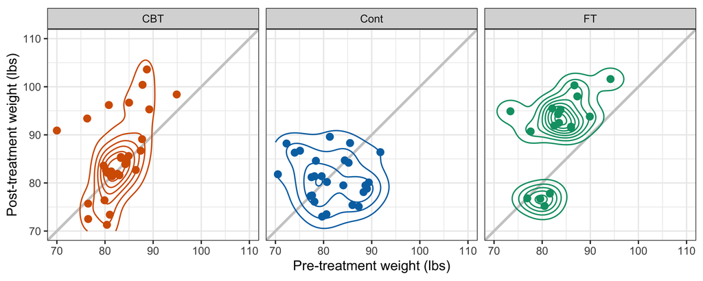

```r
data(anorexia, package="MASS")
ggplot(data=anorexia,
 aes(x=Prewt, y=Postwt,
    colour=Treat)) +
 coord_equal() +
 xlim(c(70, 110)) + ylim(c(70, 110)) +
 xlab("Pre-treatment weight (lbs)") +
 ylab("Post-treatment weight (lbs)") +
 geom_abline(intercept=0, slope=1,
   colour="grey80", linewidth=1.25) +
 geom_density2d() +
 geom_point(size=3) +
 facet_grid(.~Treat) +
 theme(legend.position = "none")
```

- Primary comparison is before treatment weight, and after treatment weight.
- Three different treatments.

[Unwin, Hofmann and Cook (2013)](https://journal.r-project.org/articles/RJ-2013-012/)

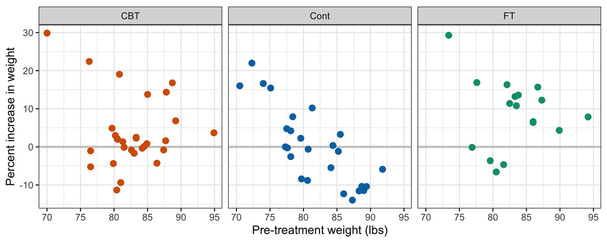

```r
ggplot(data=anorexia,
  aes(x=Prewt, colour=Treat,
    y=(Postwt-Prewt)/Prewt*100)) +
  xlab("Pre-treatment weight (lbs)") +
  ylab("Percent increase in weight") +
  geom_hline(yintercept=0, linewidth=1.25,
    colour="grey80") +
  geom_point(size=3) +
  facet_grid(.~Treat) +
 theme(legend.position = "none")
```

- Compute the difference
- Compare difference relative to before weight
- Before weight is used as the baseline

## Famous calibration error: ovarian cancer proteomics (2002–2005)

A 2002 study claimed a mass-spectrometry blood test could detect ovarian cancer with near-perfect accuracy — using mass spectroscopy to display proteins in serum as a series of peaks, with a computer algorithm finding patterns unique to patients with the disease. It generated enormous excitement (a commercial test, “OvaCheck,” was being built on it).

Keith Baggerly and Kevin Coombes at MD Anderson reanalyzed the underlying data and could not reproduce the reported sensitivity and specificity, tracing the problem not to the biology but to how the data had been collected and processed.

See [New York Times article](https://www.biostars.org/p/52561).

Baggerly called this style of work *forensic bioinformatics*.

- Discriminating peaks were spread across the entire spectrum, when true cancer-related protein changes should only affect a few specific peaks — a sign the “signal” wasn’t biological.
- Some of the “important” peaks fell in regions of the spectrum where the machine couldn’t have been reliably sampling proteins at all — meaning the signal was probably just instrument noise.
- Crucially, Baggerly pointed to incomplete randomization of samples as a likely source of these problems — cancer and control samples tended to be run in different batches, on different days, so any drift in the machine’s calibration between runs became perfectly confounded with disease status. The “biomarker” was picking up which day the sample went through the machine, not cancer.

## When there is no data

## Comparison when only have positives (1/2)

```r
library(ecotourism)
data(orchids)        # 302,123 rows: one row PER SIGHTING (presence-only)
data(weather)        # daily weather for every day, 2014-2024, per station
data(top_stations)

orchid_stations <- top_stations |>
  filter(organism == "orchids") |>
  pull(ws_id)

# Sightings by day and station
orchid_obs <- orchids |>
  filter(year == 2024) |>
  filter(ws_id %in% orchid_stations) |>
  summarise(count = n(), .by = c(date, ws_id))

# Weather by day and station
weather_2024 <- weather |>
  filter(year == 2024) |>
  filter(ws_id %in% orchid_stations)
```

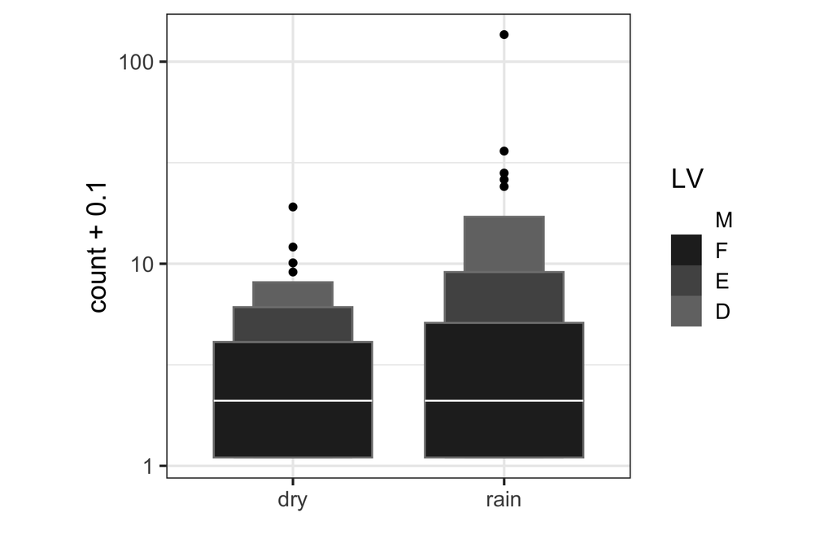

```r
orchid_date <- orchid_obs |>
  left_join(weather_2024, by = c("ws_id", "date")) |>
  filter(!is.na(prcp)) |>
  mutate(zero_prcp = if_else(prcp < 0.001, "dry", "rain"))

ggplot(orchid_date, aes(x=zero_prcp, y=count+0.1)) +
  geom_lv(aes(fill = after_stat(LV))) +
  scale_fill_lv() +
  scale_y_log10() +
  xlab("")
```

Are there less sightings of orchids on rainy days?

Make sure all days are included.

```r
weather_2024_tsb <- as_tsibble(weather_2024, index = date, key = ws_id)

weather_2024_tsb |> has_gaps()
```

```
# A tibble: 3 × 2
  ws_id        .gaps
  <chr>        <lgl>
1 946300-99999 FALSE
2 956410-99999 FALSE
3 956470-99999 FALSE
```

```r
orchid_obs_tsb <- as_tsibble(orchid_obs, index = date, key = ws_id)

orchid_obs_tsb |> has_gaps()
```

```
# A tibble: 3 × 2
  ws_id        .gaps
  <chr>        <lgl>
1 946300-99999 TRUE
2 956410-99999 TRUE
3 956470-99999 TRUE
```

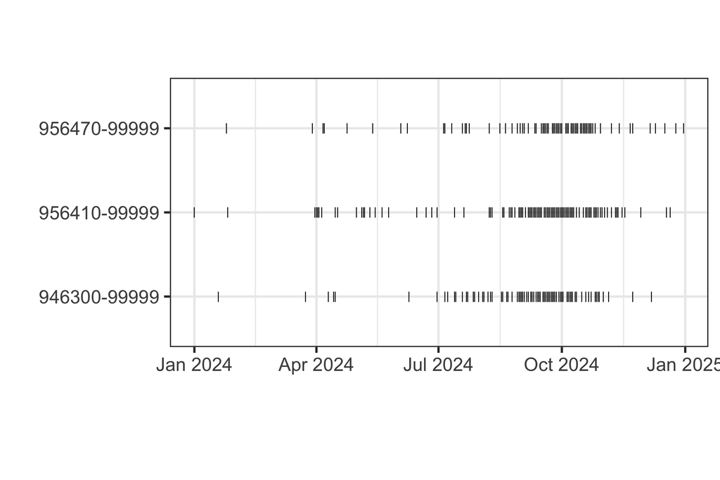

```r
ggplot(orchid_obs_tsb, aes(x=ws_id, y=date)) +
  geom_point(shape = "|") +
  xlab("") + ylab("") +
  coord_flip() +
  theme(aspect.ratio = 0.5)
```

## Comparison when only have positives (2/2)

Join using the full time data as the primary set.

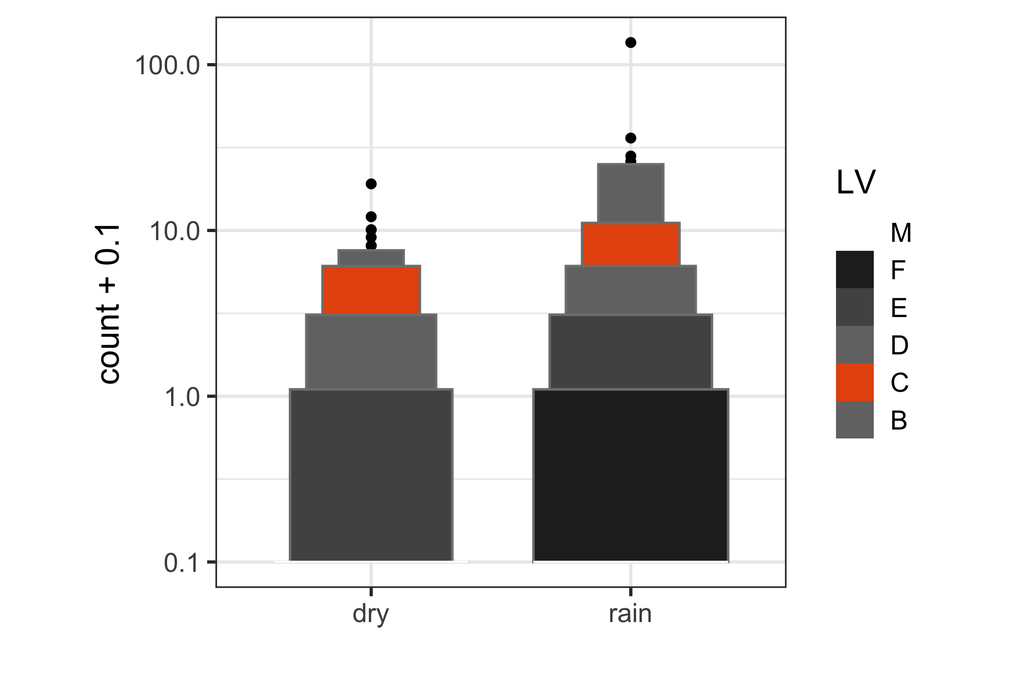

```r
weather_orchid <- weather_2024 |>
  left_join(orchid_obs, by = c("ws_id", "date")) |>
  filter(!is.na(prcp)) |>
  mutate(zero_prcp = if_else(prcp < 0.001, "dry", "rain")) |>
  mutate(count = replace_na(count, 0))

ggplot(weather_orchid, aes(x=zero_prcp, y=count+0.1)) +
  geom_lv(aes(fill = after_stat(LV))) +
  scale_fill_lv() +
  scale_y_log10() +
  xlab("")
```

Orchids are a seasonal sighting, and there might be a difference in precipitation between seasons. *Solution*: Restrict to a month where orchids are typically visible.

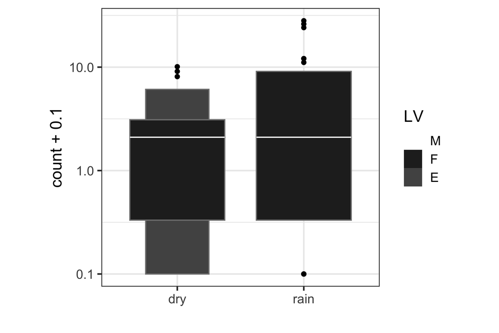

```r
weather_orchid |>
  filter(month == 10) |>
  ggplot(aes(x=zero_prcp, y=count+0.1)) +
  geom_lv(aes(fill = after_stat(LV))) +
  scale_fill_lv() +
  scale_y_log10() +
  xlab("")
```